# Tutorial for the WGCNA package for R:: Using simulated data to evaluate different module detection methods and gene screening approaches

# 1 Simulation of expression and trait data

## 1.1 Setting up the R session

Before starting, the user should choose a working directory, preferably a directory devoted exclusively for this tutorial. After starting an R session, change working directory, load the requisite packages and set standard options:

```r
# If necessary, change the path below to the directory where the data files are stored.
# "." means current directory.  On Windows use a forward slash / instead of the usual \.
workingDir <- "."
setwd(workingDir)
# Load packages
librarian::shelf(magrittr, tidyverse, data.table, glue, WGCNA, BiocParallel)
library(WGCNA)
# The following setting is important, do not omit.
options(stringsAsFactors = FALSE)
knitr::opts_chunk$set(fig.align = "center")
```

## 1.2 Simulation of expression and trait data

In this section we illustrate simulation of expression data with a simple module structure.

### 1.2.1 Building the module structure

We choose the basic parameters of the simulated data set: we will simulate 3000 genes in 50 samples. The genes will fall into five proper modules (labeled turquoise, blue, brown, green, and yellow) and a relatively large number of genes will be simulated outside of the proper modules (“grey” genes).

```r
# Here are input parameters of the simulation model
# number of samples or microarrays in the training data
no.obs <- 50
# now we specify the true measures of eigengene significance
# recall that ESturquoise=cor(y,MEturquoise)
ESturquoise <- 0
ESbrown <- -.6
ESgreen <- .6
ESyellow <- 0
# Note that we donâ€™t specify the eigengene significance of the blue module
# since it is highly correlated with the turquoise module.
ESvector <- c(ESturquoise, ESbrown, ESgreen, ESyellow)
# number of genes
nGenes1 <- 3000
# proportion of genes in the turquoise, blue, brown, green, and yellow module #respectively.
simulateProportions1 <- c(0.2, 0.15, 0.08, 0.06, 0.04)
# Note that the proportions donâ€™t add up to 1. The remaining genes will be colored grey,
# ie the grey genes are non-module genes.
# set the seed of the random number generator. As a homework exercise change this seed.
set.seed(1)
# Step 1: simulate a module eigengene network.
# Training Data Set I
MEgreen <- rnorm(no.obs)
scaledy <- MEgreen * ESgreen + sqrt(1 - ESgreen^2) * rnorm(no.obs)
y <- ifelse(scaledy > median(scaledy), 2, 1)
MEturquoise <- ESturquoise * scaledy + sqrt(1 - ESturquoise^2) * rnorm(no.obs)
# we simulate a strong dependence between MEblue and MEturquoise
MEblue <- .6 * MEturquoise + sqrt(1 - .6^2) * rnorm(no.obs)
MEbrown <- ESbrown * scaledy + sqrt(1 - ESbrown^2) * rnorm(no.obs)
MEyellow <- ESyellow * scaledy + sqrt(1 - ESyellow^2) * rnorm(no.obs)
ModuleEigengeneNetwork1 <- data.frame(y, MEturquoise, MEblue, MEbrown, MEgreen, MEyellow)
```

The variable `ModuleEigengeneNetwork1` contains the “seed” eigengenes and a simulated clinical trait `y`. The eigengene network can be simply inspected by:

```r
signif(cor(ModuleEigengeneNetwork1, use="p"),2)
```

```
                y MEturquoise MEblue MEbrown MEgreen MEyellow
y            1.00       0.050 -0.110  -0.260   0.450     0.11
MEturquoise  0.05       1.000  0.670   0.100   0.026     0.12
MEblue      -0.11       0.670  1.000   0.066  -0.190    -0.12
MEbrown     -0.26       0.100  0.066   1.000  -0.270     0.11
MEgreen      0.45       0.026 -0.190  -0.270   1.000    -0.12
MEyellow     0.11       0.120 -0.120   0.110  -0.120     1.00
```

### 1.2.2 Simulating gene expressions around the module eigengenes

The package contains a convenient function to simulate five modules which we call below:

```r
dat1 <- simulateDatExpr5Modules(
  MEturquoise = ModuleEigengeneNetwork1$MEturquoise,
  MEblue = ModuleEigengeneNetwork1$MEblue,
  MEbrown = ModuleEigengeneNetwork1$MEbrown,
  MEyellow = ModuleEigengeneNetwork1$MEyellow,
  MEgreen = ModuleEigengeneNetwork1$MEgreen,
  nGenes = nGenes1,
  simulateProportions = simulateProportions1
)
```

The simulated data (`dat1`) is a list with the following components:

```r
names(dat1)
```

```
[1] "datExpr"    "truemodule" "datME"
```

We attach the data “into the main search path” so we can use the component names directly, without referring to `dat1`:

```r
datExpr <- dat1$datExpr
truemodule <- dat1$truemodule
datME <- dat1$datME
attach(ModuleEigengeneNetwork1)
```

To see what is in the data, we can simply type

```r
table(truemodule)
```

```
truemodule
     blue     brown     green      grey turquoise    yellow
      450       240       120      1410       600       180
```

```r
dim(datExpr)
```

```
[1]   50 3000
```

The output indicated we simulated 3000 genes in 50 samples, and a large number of the genes are “grey”, i.e., genes that are not part of any proper module. the next piece of code assigns gene and sample names to columns and rows of the expression data:

```r
datExpr <- data.frame(datExpr)
ArrayName <- paste("Sample", 1:dim(datExpr)[[1]], sep = "")
# The following code is useful for outputting the simulated data
GeneName <- paste("Gene", 1:dim(datExpr)[[2]], sep = "")
dimnames(datExpr)[[1]] <- ArrayName
dimnames(datExpr)[[2]] <- GeneName
```

# 2 Loading of expression data

## 2.1 Loading of expression and trait data

In this section we illustrate loading of expression data and clinical trait. The files holding the information are provided on the main tutorial page.

```r
datGeneSummary <- read.csv("../data/GeneSummaryTutorial.csv")
datTraits <- read.csv("../data/TraitsTutorial.csv")
datMicroarrays <- read.csv("../data/MicroarrayDataTutorial.csv")
```

A quick look at the content of `datMicroarrays`:

```r
datMicroarrays[1:5,1:5]
```

|  | GeneName | Sample1 | Sample2 | Sample3 | Sample4 |
| --- | --- | --- | --- | --- | --- |
| 1 | Gene1 | -0.76903180 | 0.2010896 | -0.8929247 | 0.28616899 |
| 2 | Gene2 | -0.25281902 | 0.4293141 | -1.1007358 | 0.05983439 |
| 3 | Gene3 | 0.33073345 | -0.2741976 | 0.7029428 | 0.02233195 |
| 4 | Gene4 | 0.01335525 | 0.1155758 | -0.4554590 | 0.04184443 |
| 5 | Gene5 | 0.30580959 | 0.1004434 | -0.6086998 | -0.32522219 |

We now reformat the data and set appropriate gene and sample names:

```r
# This vector contains the microarray sample names
ArrayName <- names(data.frame(datMicroarrays[, -1]))
# This vector contains the gene names
GeneName <- datMicroarrays$GeneName
# We transpose the data so that the rows correspond to samples and the columns correspond to genes
# Since the first column contains the gene names, we exclude it.
datExpr <- data.frame(t(datMicroarrays[, -1]))
names(datExpr) <- datMicroarrays[, 1]
dimnames(datExpr)[[1]] <- names(data.frame(datMicroarrays[, -1]))
# Also, since we simulated the data, we know the true module color:
truemodule <- datGeneSummary$truemodule
rm(datMicroarrays)
```

The first few entries in `datExpr` are now

```r
datExpr[1:5,1:5]
```

|  | Gene1 | Gene2 | Gene3 | Gene4 | Gene5 |
| --- | --- | --- | --- | --- | --- |
| Sample1 | -0.7690318 | -0.25281902 | 0.33073345 | 0.01335525 | 0.3058096 |
| Sample2 | 0.2010896 | 0.42931409 | -0.27419755 | 0.11557575 | 0.1004434 |
| Sample3 | -0.8929247 | -1.10073581 | 0.70294278 | -0.45545899 | -0.6086998 |
| Sample4 | 0.2861690 | 0.05983439 | 0.02233195 | 0.04184443 | -0.3252222 |
| Sample5 | -0.6224324 | -0.61522751 | 0.80939447 | -0.46023446 | -1.0474164 |

The input gene expression data should have the above format where column names correspond to gene (or probe) names, row names correspond to array names. We now isolate the microarray trait `y` from the read data

```r
# First, make sure that the array names in the file datTraits line up with those in the microarray data
table(dimnames(datExpr)[[1]] == datTraits$ArrayName)
```

```
TRUE
  50
```

```r
# Next, define the microarray sample trait
y <- datTraits$Trait.y
```

Because the loaded data are identical to the simulated ones, we do not need to save the results here. Subsequent sections of the tutorial use the results of the data simulation section (Section 1).

# 3 Basic data pre-processing

## 3.1 Basic data pre-processing

```r
meanExpressionByArray <- apply(datExpr, 1, mean, na.rm = T)
NumberMissingByArray <- apply(is.na(data.frame(datExpr)), 1, sum)
```

A simple way to examine the mean expression per array is to use

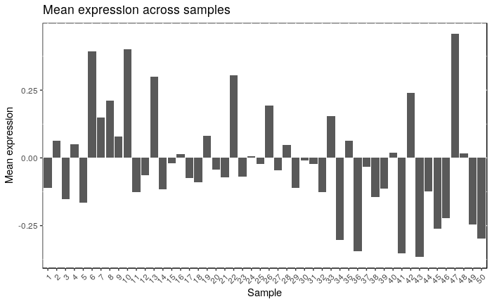

```r
tibble(sample = 1:length(meanExpressionByArray),
       meanexpression = meanExpressionByArray) %>%
  ggplot(aes(x = as.factor(sample),
             y = meanexpression)) +
  geom_col() +
  labs(x = "Sample",
       y = "Mean expression",
       title = "Mean expression across samples") +
  theme(panel.background = element_rect(fill = NA,
                                        color = 'black'),
        axis.text.x = element_text(angle = 45,
                                   hjust = 1,
                                   vjust = 1))
```

whose output is shown in Figure 3.1. No arrays in the plot seem to have an outlying mean expression value. The numbers of missing entries in each array are

```r
NumberMissingByArray
```

```
 Sample1  Sample2  Sample3  Sample4  Sample5  Sample6  Sample7  Sample8  Sample9 Sample10 Sample11 Sample12
       0        0        0        0        0        0        0        0        0        0        0        0
Sample13 Sample14 Sample15 Sample16 Sample17 Sample18 Sample19 Sample20 Sample21 Sample22 Sample23 Sample24
       0        0        0        0        0        0        0        0        0        0        0        0
Sample25 Sample26 Sample27 Sample28 Sample29 Sample30 Sample31 Sample32 Sample33 Sample34 Sample35 Sample36
       0        0        0        0        0        0        0        0        0        0        0        0
Sample37 Sample38 Sample39 Sample40 Sample41 Sample42 Sample43 Sample44 Sample45 Sample46 Sample47 Sample48
       0        0        0        0        0        0        0        0        0        0        0        0
Sample49 Sample50
       0        0
```

We note that arrays with excessive numbers of missing data should be removed, for example as

```r
# Keep only arrays containing less than 500 missing entries
KeepArray <- NumberMissingByArray < 500
table(KeepArray)
```

```
KeepArray
TRUE
  50
```

```r
datExpr <- datExpr[KeepArray, ]
y <- y[KeepArray]
ArrayName[KeepArray]
```

```
 [1] "Sample1"  "Sample2"  "Sample3"  "Sample4"  "Sample5"  "Sample6"  "Sample7"  "Sample8"  "Sample9"
[10] "Sample10" "Sample11" "Sample12" "Sample13" "Sample14" "Sample15" "Sample16" "Sample17" "Sample18"
[19] "Sample19" "Sample20" "Sample21" "Sample22" "Sample23" "Sample24" "Sample25" "Sample26" "Sample27"
[28] "Sample28" "Sample29" "Sample30" "Sample31" "Sample32" "Sample33" "Sample34" "Sample35" "Sample36"
[37] "Sample37" "Sample38" "Sample39" "Sample40" "Sample41" "Sample42" "Sample43" "Sample44" "Sample45"
[46] "Sample46" "Sample47" "Sample48" "Sample49" "Sample50"
```

### 3.1.1 Handling missing data and zero variance in probe profiles

Here we count the number of missing samples in each probe profile, and remove probes with extensive numbers of missing samples. In addition, we remove probes that do not vary at all.

```r
NumberMissingByGene <- apply(is.na(data.frame(datExpr)), 2, sum)
# One could do a barplot(NumberMissingByGene), but the barplot is empty in this case.
# It may be better to look at the numbers of missing samples using the summary method:
summary(NumberMissingByGene)
```

```
   Min. 1st Qu.  Median    Mean 3rd Qu.    Max.
      0       0       0       0       0       0
```

```r
# Calculate the variances of the probes and the number of present entries
variancedatExpr <- as.vector(apply(as.matrix(datExpr), 2, var, na.rm = T))
no.presentdatExpr <- as.vector(apply(!is.na(as.matrix(datExpr)), 2, sum))
# Another way of summarizing the number of pressent entries
table(no.presentdatExpr)
```

```
no.presentdatExpr
  50
3000
```

```r
# Keep only genes whose variance is non-zero and have at least 4 present entries
KeepGenes <- variancedatExpr > 0 & no.presentdatExpr >= 4
table(KeepGenes)
```

```
KeepGenes
TRUE
3000
```

```r
datExpr <- datExpr[, KeepGenes]
GeneName <- GeneName[KeepGenes]
```

In this case, since the data is simulated without missing data or zero-variance probes, all probes are retained.

### 3.1.2 Rudimentary detection of outlier samples

We use hierarchical clustering with the Euclidean distance to determine whether there are array (sample) outliers:

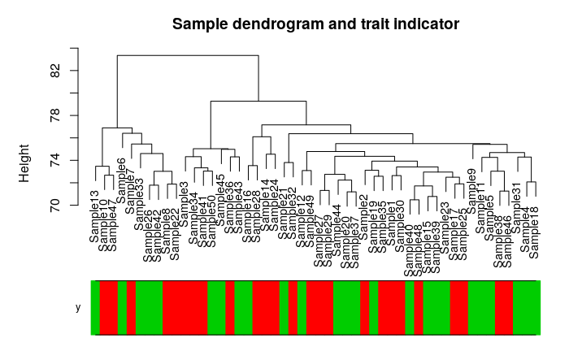

```r
sizeGrWindow(9, 5)
plotClusterTreeSamples(datExpr = datExpr, y = y)
```

# 4 Standard gene screening

## 4.1 Standard gene screening based on marginal correlation

In this section we use marginal Pearson to relate genes to the trait `y`.

```r
GS1 <- as.numeric(cor(y, datExpr, use = "p"))
# Network terminology: GS1 will be referred to as signed gene significance measure
p.Standard <- corPvalueFisher(GS1, nSamples = length(y))
# since the q-value function has problems with missing data, we use the following trick
p.Standard2 <- p.Standard
p.Standard2[is.na(p.Standard)] <- 1
q.Standard <- qvalue(p.Standard2)$qvalues
# Form a data frame to hold the results
StandardGeneScreeningResults <- data.frame(GeneName, PearsonCorrelation = GS1, p.Standard, q.Standard)
```

We take a quick look at the content of `StandardGeneScreeningResults`:

```r
head(StandardGeneScreeningResults)
```

|  | GeneName | PearsonCorrelation | p.Standard | q.Standard |
| --- | --- | --- | --- | --- |
| 1 | Gene1 | -0.01418468 | 0.9225264 | 0.9973321 |
| 2 | Gene2 | 0.08848892 | 0.5430281 | 0.9923225 |
| 3 | Gene3 | 0.02078479 | 0.8866741 | 0.9973321 |
| 4 | Gene4 | -0.02444026 | 0.8669079 | 0.9973321 |
| 5 | Gene5 | 0.06000278 | 0.6804471 | 0.9923225 |
| 6 | Gene6 | -0.11163446 | 0.4421721 | 0.9923225 |

We note that gene screening based on the Pearson correlation `GS1` is equivalent to screening based on the Student T test statistic for a fixed sample size. The reason is that the Student T-test statistic is $t = \sqrt{m − 2}∗GS1/\sqrt{1 − GS1^2}$, where `m` is the number of microarrays. Note that the `t` statistic is a monotonic function of the correlation GS1 since `m` is fixed for each gene.

### 4.1.1 Evaluation of standard screening

We now determine how many noise genes are in the top say 100 genes returned by standard screening. Recall that the eigengene significances were

```r
tibble(ESturquoise, ESbrown, ESgreen,  ESyellow)
```

| ESturquoise | ESbrown | ESgreen | ESyellow |
| --- | --- | --- | --- |
| 0 | -0.6 | 0.6 | 0 |

This implies that grey non-module genes, turquoise genes, the related blue genes, and yellow genes are noise. The following vector indicates which genes are noise (as simulated):

```r
NoiseGeneIndicator <- is.element(truemodule, c("turquoise", "blue", "yellow", "grey")) + .0
SignalGeneIndicator <- 1 - NoiseGeneIndicator
```

Note the proportion of noise among the top 20 most significant genes:

```r
mean(NoiseGeneIndicator[rank(p.Standard)<=20])
```

```
[1] 0.4
```

```r
mean(NoiseGeneIndicator[rank(p.Standard)<=200])
```

```
[1] 0.585
```

```r
mean(NoiseGeneIndicator[rank(p.Standard)<=100])
```

```
[1] 0.48
```

This implies that 48% of the top 100 most significant genes are noise. That is quite bad.  
**How many noise genes have a q-value less than or equal to 0.20?** The following code will give the answer:

```r
table(q.Standard < .20)
```

```
FALSE  TRUE
 2997     3
```

```r
mean(NoiseGeneIndicator[q.Standard <= 0.20])
```

```
[1] 0.6666667
```

# 5 Construction of a weighted gene co-expression network and network modules

```r
# here we define the adjacency matrix using soft thresholding with beta=6
ADJ1 <- abs(cor(datExpr, use = "p"))^6
# When you have relatively few genes (<5000) use the following code
k <- as.vector(apply(ADJ1, 2, sum, na.rm = T))
# When you have a lot of genes use the following code
k <- softConnectivity(datE = datExpr, power = 6)
```

```
 softConnectivity: FYI: connecitivty of genes with less than 17 valid samples will be returned as NA.
 ..calculating connectivities.. ..0% ..50% ..100%
```

| scaleFreeRsquared | slope |
| --- | --- |
| 0.91 | -2.08 |

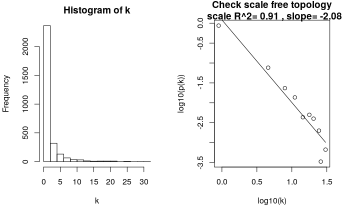

```r
# Plot a histogram of k and a scale free topology plot
sizeGrWindow(10, 5)
par(mfrow = c(1, 2))
hist(k)
scaleFreePlot(k, main = "Check scale free topology\n")
```

The resulting plot is shown in Figure 5.1. The approximate straight line relationship (high *R^2* value, right panel in Figure 5.1) shows approximate scale free topology. In most applications we find that scale free topology is at least approximately satisfied when a high power is chosen for defining the adjacency matrix. We should point out that is not necessary that a network satisfies scale free topology; scale free topology may not be satisfied if the data are comprised of globally very distinct groups of samples (e.g. different tissues types). Poor fit to scale free topology may also indicate the presence of array outliers.

## 5.1 Computational restrictions on the number of genes

For computational reasons, we restrict the network analysis to 3600 most connected genes

```r
datExpr <- datExpr[, rank(-k, ties.method = "first") <= 3600]
```

This restriction is only necessary when constructing the network in a step-by-step, “manual” way. The user can also use the automatic one-step function `blockwiseModules` that is able to handle large data sets. We refer the reader to Tutorials I, II (mouse data analysis) for examples of using the automatic function on large data sets.

## 5.2 Comparing various module detection methods

### 5.2.1 Definition of clustering dissimilarity from adjacency

Many clustering procedures require a dissimilarity matrix as input. We define a dissimilarity based on adjacency:

```r
# Turn adjacency into a measure of dissimilarity
dissADJ <- 1 - ADJ1
```

### 5.2.2 Use of topologial overlap to define dissimilarity

Adjacency can be used to define a separate measure of similarity, the Topological Overlap Matrix(TOM) [2, 1]:

```r
dissTOM <- 1-TOMsimilarity(ADJ1, TOMType = "unsigned")
```

```
..connectivity..
..matrix multiplication (system BLAS)..
..normalization..
..done.
```

In the following subsections we show that Partitioning Around Medoids (PAM) is not a good choice for clustering genes because it forces all genes into a module. We then illustrate the use of hierarchical clustering and several branch cut methods.

### 5.2.3 Partitioning Around Medoids based on adjacency

We use PAM with 3 different numbers of clusters:

```r
pam4 <- pam(as.dist(dissADJ), 4)
pam5 <- pam(as.dist(dissADJ), 5)
pam6 <- pam(as.dist(dissADJ), 6)
# Cross-tabulte the detected and the true (simulated) module membership:
table(pam4$clustering, truemodule)
```

```
   truemodule
    blue brown green grey turquoise yellow
  1   51     8    17  792       530      1
  2  380    10    34  261        37      6
  3   12     4    17  167        17    172
  4    7   218    52  190        16      1
```

```r
table(pam5$clustering, truemodule)
```

```
   truemodule
    blue brown green grey turquoise yellow
  1   50     5     2  742       524      1
  2  373    10     3  234        35      6
  3   11     3     2  142        15    170
  4    9     7   107  133        16      2
  5    7   215     6  159        10      1
```

```r
table(pam6$clustering, truemodule)
```

```
   truemodule
    blue brown green grey turquoise yellow
  1   39     3     1  440       310      1
  2   21     5     3  412       235      1
  3  363    10     3  186        26      6
  4   11     3     2  119         8    169
  5    9     6   106  119        14      2
  6    7   213     5  134         7      1
```

The rows correspond to clusters found by PAM, while the columns correspond to simulated modules. Numbers in the table are gene counts in the intersection of the respective simulated and found modules. PAM performs terribly on this data set since the grey, non-module genes are “forced” into the observed modules (corresponding to the rows). In general, partitioning methods that dont allow for unclustered objects will have a problem on this simulated data set.

### 5.2.4 Partitioning Around Medoids based on topological overlap

We again use PAM with the same three different numbers of clusters:

```r
pamTOM4 <- pam(as.dist(dissTOM), 4)
pamTOM5 <- pam(as.dist(dissTOM), 5)
pamTOM6 <- pam(as.dist(dissTOM), 6)
# Cross-tabulte the detected and the true (simulated) module membership:
table(pamTOM4$clustering, truemodule)
```

```
   truemodule
    blue brown green grey turquoise yellow
  1   58    15    34 1100       576     10
  2  384    11    48  197        21      9
  3    3     2     4   42         2    159
  4    5   212    34   71         1      2
```

```r
table(pamTOM5$clustering, truemodule)
```

```
   truemodule
    blue brown green grey turquoise yellow
  1   58    13     9 1087       574     10
  2  384    10     7  190        20      9
  3    0     4    97   28         3      0
  4    3     2     0   40         2    159
  5    5   211     7   65         1      2
```

```r
table(pamTOM6$clustering, truemodule)
```

```
   truemodule
    blue brown green grey turquoise yellow
  1   49    11     7  808       475      8
  2    9     2     2  285        99      2
  3  384    10     7  185        20      9
  4    0     4    97   28         3      0
  5    3     2     0   40         2    159
  6    5   211     7   64         1      2
```

As above, the rows correspond to clusters found by PAM, while the columns correspond to simulated modules. Numbers in the table are gene counts in the intersection of the respective simulated and found modules. The performance of pam is not good. This is why we will use hierarchical clustering.

### 5.2.5 Average linkage hierachical clustering with adjacency-based dissimilarity

Here we illustrate the use of average linkage hierachical clustering.

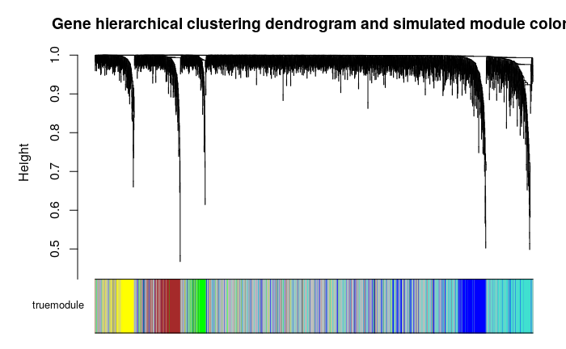

```r
hierADJ <- hclust(as.dist(dissADJ), method = "average")
# Plot the resulting clustering tree together with the true color assignment
sizeGrWindow(10, 5)
plotDendroAndColors(hierADJ,
  colors = data.frame(truemodule), dendroLabels = FALSE, hang = 0.03,
  main = "Gene hierarchical clustering dendrogram and simulated module colors"
)
```

The result is shown in Figure 5.2. Note that the branches correspond to the true modules. The question now is how should we cut the branches of the dendrogram to determine module membership?

### 5.2.6 Module definition via static (fixed) height cut-off

By our definition, modules correspond to branches of the tree. The question is what height cut-off should be used? This depends on the biology. Large heigth values lead to big modules, small values lead to small but tight modules.  
In reality, the user should use different thresholds `h1` (red below) to assess how robust the findings are. The function `cutreeStaticColor` colors each gene by the branches that result from choosing a particular height cut-off. The label “grey” is reserved to color genes that are not part of any module. Here we only consider modules that contain at least minSize genes

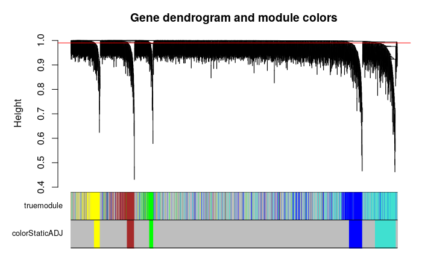

```r
colorStaticADJ <- as.character(cutreeStaticColor(hierADJ, cutHeight = .99, minSize = 20))
# Plot the dendrogram with module colors
sizeGrWindow(10, 5)
plotDendroAndColors(hierADJ,
  colors = data.frame(truemodule, colorStaticADJ),
  dendroLabels = FALSE, abHeight = 0.99,
  main = "Gene dendrogram and module colors"
)
```

The resulting plot is shown in Figure 5.3. The static height cut-off method works quite well at retrieving the true modules. More precisely, it works well at retrieving highly connected intramodular hub genes in the modules. However, it misses a lot of genes at the fringes of the modules.

### 5.2.7 Module definition via dynamic branch cutting methods

We now use two Dynamic Tree Cut methods in which the height cut-off plays a minor role. The first method is called the “tree” method and only uses the dendrogram as input.

```r
branch.number <- cutreeDynamic(hierADJ, method = "tree")
# This function transforms the branch numbers into colors
colorDynamicADJ <- labels2colors(branch.number)
```

The second method is called “hybrid” and is a hybrid between hclust and pam. As input it requires both a dendrogram and the dissimilarity that was used to create the dendrogram.

```r
colorDynamicHybridADJ <- labels2colors(cutreeDynamic(hierADJ,
  distM = dissADJ,
  cutHeight = 0.998, deepSplit = 2, pamRespectsDendro = FALSE
))
```

```
 ..done.
```

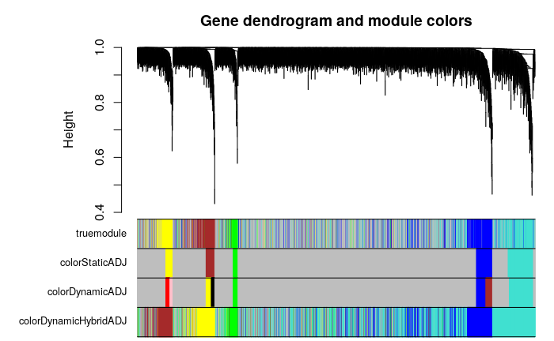

```r
# Plot results of all module detection methods together:
sizeGrWindow(10, 5)
plotDendroAndColors(
  dendro = hierADJ,
  colors = data.frame(
    truemodule, colorStaticADJ,
    colorDynamicADJ, colorDynamicHybridADJ
  ),
  dendroLabels = FALSE, marAll = c(0.2, 8, 2.7, 0.2),
  main = "Gene dendrogram and module colors"
)
```

### 5.2.8 Module definition using the topological overlap based dissimilarity

We now use the topological overlap based dissimilarity as input to the clustering methods we used above

```r
# Calculate the dendrogram
hierTOM <- hclust(as.dist(dissTOM), method = "average")
# The reader should vary the height cut-off parameter h1
# (related to the y-axis of dendrogram) in the following
colorStaticTOM <- as.character(cutreeStaticColor(hierTOM, cutHeight = .99, minSize = 20))
colorDynamicTOM <- labels2colors(cutreeDynamic(hierTOM, method = "tree"))
colorDynamicHybridTOM <- labels2colors(cutreeDynamic(hierTOM,
  distM = dissTOM, cutHeight = 0.998,
  deepSplit = 2, pamRespectsDendro = FALSE
))
```

```
 ..done.
```

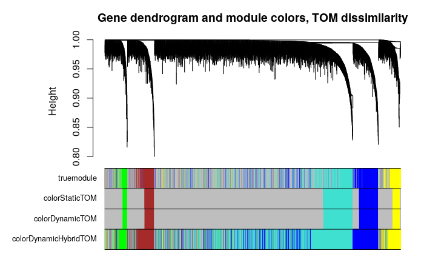

```r
# Now we plot the results
sizeGrWindow(10, 5)
plotDendroAndColors(hierTOM,
  colors = data.frame(
    truemodule, colorStaticTOM,
    colorDynamicTOM, colorDynamicHybridTOM
  ),
  dendroLabels = FALSE, marAll = c(1, 8, 3, 1),
  main = "Gene dendrogram and module colors, TOM dissimilarity"
)
```

The result is shown in Figure 5.5. The dynamic hybrid method leads to modules that are slightly too large. In practice this would not be a problem since one typically focuses on the tip of the branches (highly connected hub genes). Also it would have a very small effect on the definition of the module eigengenes.

### 5.2.9 Which dissimilarity measure and which branch cutting method performs best in this data set?

The answer depends on threshold parameters used for branch cutting. For illustration, we carry out a brute force comparison. In the following, we create tables for relating the different module assignements to the true module colors.

```r
tabStaticADJ <- table(colorStaticADJ, truemodule)
tabStaticTOM <- table(colorStaticTOM, truemodule)
tabDynamicADJ <- table(colorDynamicADJ, truemodule)
tabDynamicTOM <- table(colorDynamicTOM, truemodule)
tabDynamicHybridADJ <- table(colorDynamicHybridADJ, truemodule)
tabDynamicHybridTOM <- table(colorDynamicHybridTOM, truemodule)
```

Next, we use the (unadjusted) Rand index to measure agreement. This computes the Rand index for each table:

```r
randIndex(tabStaticADJ, adjust = F)
```

```
[1] 0.5072126
```

```r
randIndex(tabStaticTOM, adjust = F)
```

```
[1] 0.5997922
```

```r
randIndex(tabDynamicADJ, adjust = F)
```

```
[1] 0.5033845
```

```r
randIndex(tabDynamicTOM, adjust = F)
```

```
[1] 0.5980453
```

```r
randIndex(tabDynamicHybridADJ, adjust = F)
```

```
[1] 0.7054071
```

```r
randIndex(tabDynamicHybridTOM, adjust = F)
```

```
[1] 0.7039642
```

In this data set, dissTOM performs better than dissADJ for the first two branch cutting method. The results for the Dynamic Hybrid methods are very similar. In the following, we will proceed with the observed modules from DynamicHybridTOM. Here is the cross tabulation of colorDynamicHybridTOM with the true module assignment:

```r
tabDynamicHybridTOM
```

```
                     truemodule
colorDynamicHybridTOM blue brown green grey turquoise yellow
            blue       377     8     4  163        30      7
            brown        5   211     5   68         3      1
            green        0     4    95   35         4      0
            grey        26    11    11  326        28      6
            turquoise   35     4     4  754       530      3
            yellow       7     2     1   64         5    163
```

We define a shorter name for the module assignemnt of choice:

```r
colorh1 <- colorDynamicHybridTOM
# remove the dissimilarities, adjacency matrices etc to free up space
rm(ADJ1)
rm(dissADJ)
```

```r
datME <- moduleEigengenes(datExpr, colorh1)$eigengenes
signif(cor(datME, use = "p"), 2)
```

[output not shown]

```r
dissimME <- (1 - t(cor(datME, method = "p"))) / 2
hclustdatME <- hclust(as.dist(dissimME), method = "average")
# Plot the eigengene dendrogram
par(mfrow = c(1, 1))
plot(hclustdatME, main = "Clustering tree based of the module eigengenes")
```

[output not shown]

```r
sizeGrWindow(8, 9)
plotMEpairs(datME, y = y)
```

[output not shown]

```r
signif(cor(datME, ModuleEigengeneNetwork1[, -1]), 2)
```

[output not shown]

```r
sizeGrWindow(8, 9)
par(mfrow = c(3, 1), mar = c(1, 2, 4, 1))
which.module <- "turquoise"
plotMat(t(scale(datExpr[, colorh1 == which.module ])),
  nrgcols = 30, rlabels = T,
  clabels = T, rcols = which.module,
  title = which.module
)
# for the second (blue) module we use
which.module <- "blue"
plotMat(t(scale(datExpr[, colorh1 == which.module ])),
  nrgcols = 30, rlabels = T,
  clabels = T, rcols = which.module,
  title = which.module
)
which.module <- "brown"
plotMat(t(scale(datExpr[, colorh1 == which.module ])),
  nrgcols = 30, rlabels = T,
  clabels = T, rcols = which.module,
  title = which.module
)
```

[output not shown]

```r
sizeGrWindow(8, 7)
which.module <- "green"
ME <- datME[, paste("ME", which.module, sep = "")]
par(mfrow = c(2, 1), mar = c(0.3, 5.5, 3, 2))
plotMat(t(scale(datExpr[, colorh1 == which.module ])),
  nrgcols = 30, rlabels = F, rcols = which.module,
  main = which.module, cex.main = 2
)
par(mar = c(5, 4.2, 0, 0.7))
barplot(ME,
  col = which.module, main = "", cex.main = 2,
  ylab = "eigengene expression", xlab = "array sample"
)
```

[output not shown]

```r
signif(cor(y, datME, use = "p"), 2)
```

[output not shown]

```r
cor.test(y, datME$MEbrown)
```

[output not shown]

```r
p.values <- corPvalueStudent(cor(y, datME, use = "p"), nSamples = length(y))
```

```r
GS1 <- as.numeric(cor(y, datExpr, use = "p"))
GeneSignificance <- abs(GS1)
# Next module significance is defined as average gene significance.
ModuleSignificance <- tapply(GeneSignificance, colorh1, mean, na.rm = T)
```

```r
sizeGrWindow(8, 7)
par(mfrow = c(1, 1))
plotModuleSignificance(GeneSignificance, colorh1)
```

[output not shown]

```r
ADJ1 <- abs(cor(datExpr, use = "p"))^6
Alldegrees1 <- intramodularConnectivity(ADJ1, colorh1)
head(Alldegrees1)
```

[output not shown]

```r
colorlevels <- unique(colorh1)
sizeGrWindow(9, 6)
par(mfrow = c(2, as.integer(0.5 + length(colorlevels) / 2)))
par(mar = c(4, 5, 3, 1))
for (i in c(1:length(colorlevels)))
{
  whichmodule <- colorlevels[[i]]
  restrict1 <- (colorh1 == whichmodule)
  verboseScatterplot(Alldegrees1$kWithin[restrict1],
    GeneSignificance[restrict1],
    col = colorh1[restrict1],
    main = whichmodule,
    xlab = "Connectivity", ylab = "Gene Significance", abline = TRUE
  )
}
```

[output not shown]

```r
datKME <- signedKME(datExpr, datME, outputColumnName = "MM.")
# Display the first few rows of the data frame
head(datKME)
```

[output not shown]

```r
FilterGenes <- abs(GS1) > .2 & abs(datKME$MM.brown) > .8
table(FilterGenes)
```

[output not shown]

```r
dimnames(data.frame(datExpr))[[2]][FilterGenes]
```

[output not shown]

```r
sizeGrWindow(8, 6)
par(mfrow = c(2, 2))
# We choose 4 modules to plot: turquoise, blue, brown, green.
# For simplicity we write the code out explicitly for each module.
which.color <- "turquoise"
restrictGenes <- colorh1 == which.color
verboseScatterplot(Alldegrees1$kWithin[ restrictGenes],
  (datKME[restrictGenes, paste("MM.", which.color, sep = "")])^6,
  col = which.color,
  xlab = "Intramodular Connectivity",
  ylab = "(Module Membership)^6"
)

which.color <- "blue"
restrictGenes <- colorh1 == which.color
verboseScatterplot(Alldegrees1$kWithin[ restrictGenes],
  (datKME[restrictGenes, paste("MM.", which.color, sep = "")])^6,
  col = which.color,
  xlab = "Intramodular Connectivity",
  ylab = "(Module Membership)^6"
)

which.color <- "brown"
restrictGenes <- colorh1 == which.color
verboseScatterplot(Alldegrees1$kWithin[ restrictGenes],
  (datKME[restrictGenes, paste("MM.", which.color, sep = "")])^6,
  col = which.color,
  xlab = "Intramodular Connectivity",
  ylab = "(Module Membership)^6"
)

which.color <- "green"
restrictGenes <- colorh1 == which.color
verboseScatterplot(Alldegrees1$kWithin[ restrictGenes],
  (datKME[restrictGenes, paste("MM.", which.color, sep = "")])^6,
  col = which.color,
  xlab = "Intramodular Connectivity",
  ylab = "(Module Membership)^6"
)
```

[output not shown]

```r
NS1 <- networkScreening(
  y = y, datME = datME, datExpr = datExpr,
  oddPower = 3, blockSize = 1000, minimumSampleSize = 4,
  addMEy = TRUE, removeDiag = FALSE, weightESy = 0.5
)
```

```r
# network screening analysis
mean(NoiseGeneIndicator[rank(NS1$p.Weighted, ties.method = "first") <= 100])
# standard analysis based on the correlation p-values (or Student T test)
mean(NoiseGeneIndicator[rank(NS1$p.Standard, ties.method = "first") <= 100])
```

[output not shown]

```r
topNumbers <- c(10, 20, 50, 100)
for (i in c(1:length(topNumbers)))
{
  print(paste("Proportion of noise genes in the top", topNumbers[i], "list"))
  WGCNApropNoise <- mean(NoiseGeneIndicator[rank(NS1$p.Weighted, ties.method = "first") <= topNumbers[i]])
  StandardpropNoise <- mean(NoiseGeneIndicator[rank(NS1$p.Standard, ties.method = "first") <= topNumbers[i]])
  print(paste(
    "WGCNA, proportion of noise=", WGCNApropNoise,
    ", Standard, prop. noise=", StandardpropNoise
  ))
  if (WGCNApropNoise < StandardpropNoise) print("WGCNA wins")
  if (WGCNApropNoise == StandardpropNoise) print("both methods tie")
  if (WGCNApropNoise > StandardpropNoise) print("standard screening wins")
}
```

[output not shown]

```r
# Form a data frame containing standard and network screening results
CorPrediction1 <- data.frame(GS1, NS1$cor.Weighted)
cor.Weighted <- NS1$cor.Weighted
# Plot the comparison
sizeGrWindow(8, 6)
verboseScatterplot(cor.Weighted, GS1,
  main = "Network-based weighted correlation versus Pearson correlation\n",
  col = truemodule, cex.main = 1.2
)
abline(0, 1)
```

[output not shown]

```r
set.seed(2)
nSamples2 <- 2000
MEgreen <- rnorm(nSamples2)
scaledy2 <- MEgreen * ESgreen + sqrt(1 - ESgreen^2) * rnorm(nSamples2)
y2 <- ifelse(scaledy2 > median(scaledy2), 2, 1)
MEturquoise <- ESturquoise * scaledy2 + sqrt(1 - ESturquoise^2) * rnorm(nSamples2)
# we simulate a strong dependence between MEblue and MEturquoise
MEblue <- .6 * MEturquoise + sqrt(1 - .6^2) * rnorm(nSamples2)
MEbrown <- ESbrown * scaledy2 + sqrt(1 - ESbrown^2) * rnorm(nSamples2)
MEyellow <- ESyellow * scaledy2 + sqrt(1 - ESyellow^2) * rnorm(nSamples2)
# Put together a data frame of eigengenes
ModuleEigengeneNetwork2 <- data.frame(y = y2, MEturquoise, MEblue, MEbrown, MEgreen, MEyellow)
# Simulate the expression data
dat2 <- simulateDatExpr5Modules(
  MEturquoise = ModuleEigengeneNetwork2$MEturquoise,
  MEblue = ModuleEigengeneNetwork2$MEblue, MEbrown = ModuleEigengeneNetwork2$MEbrown,
  MEyellow = ModuleEigengeneNetwork2$MEyellow,
  MEgreen = ModuleEigengeneNetwork2$MEgreen, simulateProportions = simulateProportions1,
  nGenes = nGenes1
)
# recall that this is the signed gene significance in the training data
GS1 <- as.numeric(cor(y, datExpr, use = "p"))
# the following is the signed gene significance in the test data
GS2 <- as.numeric(cor(ModuleEigengeneNetwork2$y, dat2$datExpr, use = "p"))
```

```r
sizeGrWindow(8, 6)
par(mfrow = c(1, 1))
verboseScatterplot(GS1, GS2,
  main = "Trait-based gene significance in test set vs. training set\n",
  xlab = "Training set gene significance",
  ylab = "Test set gene significance",
  col = truemodule, cex.main = 1.4
)
```

[output not shown]

```r
EvaluationGeneScreening1 <- corPredictionSuccess(
  corPrediction = CorPrediction1,
  corTestSet = GS2,
  topNumber = seq(from = 20, to = 500, length = 30)
)
par(mfrow = c(2, 2))
listcomp <- EvaluationGeneScreening1$meancorTestSetOverall
matplot(
  x = listcomp$topNumber,
  y = listcomp[, -1],
  main = "Predicting positive and negative correlations",
  ylab = "mean cor, test data",
  xlab = "top number of genes in the training data"
)
listcomp <- EvaluationGeneScreening1$meancorTestSetPositive
matplot(
  x = listcomp$topNumber,
  y = listcomp[, -1],
  main = "Predicting positive correlations",
  ylab = "mean cor, test data",
  xlab = "top number of genes in the training data"
)
listcomp <- EvaluationGeneScreening1$meancorTestSetNegative
matplot(
  x = listcomp$topNumber,
  y = listcomp[, -1],
  main = "Predicting negative correlations",
  ylab = "mean cor, test data",
  xlab = "top number of genes in the training data"
)
```

[output not shown]

```r
relativeCorPredictionSuccess(
  corPredictionNew = NS1$cor.Weighted,
  corPredictionStandard = GS1,
  corTestSet = GS2,
  topNumber = c(10, 20, 50, 100, 200, 500)
)
```

[output not shown]

```r
# Create a data frame holding the results of gene screening
GeneResultsNetworkScreening <- data.frame(GeneName = row.names(NS1), NS1)
# Write the data frame into a file
write.table(GeneResultsNetworkScreening,
  file = "GeneResultsNetworkScreening.csv",
  row.names = F, sep = ","
)
# Output of eigengene information:
datMEy <- data.frame(y, datME)
eigengeneSignificance <- cor(datMEy, y)
eigengeneSignificance[1, 1] <- (1 + max(eigengeneSignificance[-1, 1])) / 2
eigengeneSignificance.pvalue <- corPvalueStudent(eigengeneSignificance, nSamples = length(y))
namesME <- names(datMEy)
# Form a summary data frame
out1 <- data.frame(t(data.frame(
  eigengeneSignificance,
  eigengeneSignificance.pvalue, namesME, t(datMEy)
)))
# Set appropriate row names
dimnames(out1)[[1]][1] <- "EigengeneSignificance"
dimnames(out1)[[1]][2] <- "EigengeneSignificancePvalue"
dimnames(out1)[[1]][3] <- "ModuleEigengeneName"
dimnames(out1)[[1]][-c(1:3)] <- dimnames(datExpr)[[1]]
# Write the data frame into a file
write.table(out1, file = "MEResultsNetworkScreening.csv", row.names = TRUE, col.names = TRUE, sep = ",")
# Display the first few rows:
head(out1)
```

[output not shown]

```r
# Write out gene information
GeneName <- dimnames(datExpr)[[2]]
GeneSummary <- data.frame(GeneName, truemodule, SignalGeneIndicator, NS1)
write.table(GeneSummary, file = "GeneSummaryTutorial.csv", row.names = F, sep = ",")
# here we output the module eigengenes and trait y without eigengene significances
datTraits <- data.frame(ArrayName, datMEy)
dimnames(datTraits)[[2]][2:length(namesME)] <- paste("Trait",
  dimnames(datTraits)[[2]][2:length(namesME)],
  sep = "."
)
write.table(datTraits, file = "TraitsTutorial.csv", row.names = F, sep = ",")
# here we output the simulated gene expression data
MicroarrayData <- data.frame(GeneName, t(datExpr))
names(MicroarrayData)[-1] <- ArrayName
write.table(MicroarrayData, file = "MicroarrayDataTutorial.csv", row.names = F, sep = ",")
```

```r
# Perform network screening
NS1GS <- networkScreeningGS(datExpr = datExpr, datME = datME, GS = GS1)
# Organize its results for easier plotting
GSprediction1 <- data.frame(GS1, NS1GS$GS.Weighted)
GS.Weighted <- NS1GS$GS.Weighted
# Plot a comparison between standard gene significance and network-weighted gene significance
sizeGrWindow(8, 6)
par(mfrow = c(1, 1))
verboseScatterplot(GS1, GS.Weighted,
  main = "Weighted gene significance vs. the standard GS\n",
  col = truemodule
)
abline(0, 1)
```

[output not shown]

```r
EvaluationGeneScreeningGS <- corPredictionSuccess(
  corPrediction = GSprediction1, corTestSet = GS2,
  topNumber = seq(from = 20, to = 500, length = 30)
)
sizeGrWindow(8, 6)
par(mfrow = c(2, 2))
listcomp <- EvaluationGeneScreeningGS$meancorTestSetOverall
matplot(
  x = listcomp$topNumber,
  y = listcomp[, -1],
  main = "Predicting positive and negative correlations",
  ylab = "mean cor, test data",
  xlab = "top number of genes in the training data"
)
listcomp <- EvaluationGeneScreeningGS$meancorTestSetPositive
matplot(
  x = listcomp$topNumber,
  y = listcomp[, -1],
  main = "Predicting positive correlations",
  ylab = "mean cor, test data",
  xlab = "top number of genes in the training data"
)
listcomp <- EvaluationGeneScreeningGS$meancorTestSetNegative
matplot(
  x = listcomp$topNumber,
  y = listcomp[, -1],
  main = "Predicting negative correlations",
  ylab = "mean cor, test data",
  xlab = "top number of genes in the training data"
)
```

[output not shown]

```r
cmd1 <- cmdscale(as.dist(dissTOM), 2)
sizeGrWindow(7, 6)
par(mfrow = c(1, 1))
plot(cmd1,
  col = as.character(colorh1), main = "MDS plot",
  xlab = "Scaling Dimension 1", ylab = "Scaling Dimension 2"
)
```

[output not shown]

```r
power <- 6
color1 <- colorDynamicTOM
restGenes <- (color1 != "grey")
diss1 <- 1 - TOMsimilarityFromExpr(datExpr[, restGenes], power = 6)
hier1 <- hclust(as.dist(diss1), method = "average")
diag(diss1) <- NA
sizeGrWindow(7, 7)
TOMplot(diss1^4, hier1, as.character(color1[restGenes]),
  main = "TOM heatmap plot, module genes"
)
```

[output not shown]

```r
power <- 6
color1 <- colorDynamicTOM
restGenes <- (color1 != "grey")
diss1 <- 1 - adjacency(datExpr[, restGenes], power = 6)
hier1 <- hclust(as.dist(diss1), method = "average")
diag(diss1) <- NA
sizeGrWindow(7, 7)
TOMplot(diss1^4, hier1, as.character(color1[restGenes]),
  main = "Adjacency heatmap plot, module genes"
)
```

[output not shown]

```r
sizeGrWindow(7, 7)
topList <- rank(NS1$p.Weighted, ties.method = "first") <= 30
gene.names <- names(datExpr)[topList]
# The following shows the correlations between the top genes
plotNetworkHeatmap(datExpr,
  plotGenes = gene.names,
  networkType = "signed", useTOM = FALSE,
  power = 1, main = "signed correlations"
)
```

[output not shown]

```r
sizeGrWindow(7, 7)
# The following shows the correlations between the top genes
plotNetworkHeatmap(datExpr,
  plotGenes = gene.names,
  networkType = "unsigned", useTOM = FALSE,
  power = 1, main = "signed correlations"
)
```

[output not shown]

```r
sizeGrWindow(7, 7)
# The following shows the TOM heatmap in a signed network
plotNetworkHeatmap(datExpr,
  plotGenes = gene.names,
  networkType = "signed", useTOM = TRUE,
  power = 12, main = "C. TOM in a signed network"
)
# The following shows the TOM heatmap in a unsigned network
plotNetworkHeatmap(datExpr,
  plotGenes = gene.names,
  networkType = "unsigned", useTOM = TRUE,
  power = 6, main = "D. TOM in an unsigned network"
)
```

[output not shown]